# Zuckerberg Testimony - Sentiment Analysis

Asha Mehrer

```python
#annoying bit about python: lack of native floating point division
from __future__ import division
```

```python
# import module(s) into namespace
import pandas as pd
import numpy as np
pd.set_option('display.max_colwidth', 15000) #important for getting all the text
```

#### Function to generate word clouds from text

```python
#http://blackecho.github.io/tweet_data_viz.html
#http://diglibarts.whittier.edu/tos-word-clouds/
from PIL import Image
from wordcloud import WordCloud, STOPWORDS, ImageColorGenerator
import os
import matplotlib.pyplot as plt
from scipy.misc import imread

def show_words_cloud(text, stopwords, count, like=None):
    if like is None:
        location = os.path.realpath(os.path.join(os.getcwd(), 'fbmask.png'))
    elif (like):
        location = os.path.realpath(os.path.join(os.getcwd(), 'like_mask.png'))
    else:
        location = os.path.realpath(os.path.join(os.getcwd(), 'dislike_mask.png'))
    #print(location)
    image = Image.open(location)
    fb_mask = np.array(image)
    colorMask = os.path.realpath(os.path.join(os.getcwd(),"fbcolor.png"))
    fb_color = np.array(Image.open(colorMask))
    wcloud = WordCloud(collocations=False, background_color='white',max_words=count,
                       mask=fb_mask, max_font_size=90,
                       stopwords=stopwords, width=225,
                       height=225, random_state=997, font_path = "fbfont.OTF")

    wcloud.generate(text)
    image_colors = ImageColorGenerator(fb_color)
    wcloud.recolor(color_func=image_colors)
    plt.figure(figsize=(20,10))
    plt.imshow(wcloud, interpolation='bilinear')
    plt.axis("off")
    plt.tight_layout(pad=0)
    plt.show()
```

### Import csv from Kaggle

We're going to read in the testimony as a CSV file, with 2 columns - speaker name and text spoken, instantiate a vectorizer, and look at the top features

```python
testimonyDF = pd.read_csv("mark.csv")
print(testimonyDF.shape)
print(list(testimonyDF)) #feature space
```

```
(858, 2)
['Person', 'Text']
```

```python
#change everything to lower case
testimonyDF['Text'] = testimonyDF["Text"].apply(lambda x: x.lower())
```

```python
testimonyDF[0:3]
```

|  | Person | Text |
| --- | --- | --- |
| 0 | GRASSLEY: | i'll start with you.\r\n\r\nfacebook handles extensive amounts of personal data for billions of users. a significant amount of that data is shared with third-party developers, who utilize your platfor… |
| 1 | ZUCKERBERG: | mr. chairman, thank you.\r\n\r\nas i mentioned, we're now conducting a full investigation into every single app that had a -- access to a large amount of information, before we locked down platform to… |
| 2 | GRASSLEY: | ok (ph).\r\n\r\nhave you ever required an audit to ensure the deletion of improperly transferred data? and, if so, how many times?\r\n\r\n |

#### Analyze raw data to identify frequent words, help build stop words and identify the processing required for this analysis

```python
from sklearn.feature_extraction.text import CountVectorizer


boldStart = "\033[1m"
boldEnd = "\033[0;0m"

def featureCounts(vectorizer, *features):
    for feature in features:
        cv_dm = vectorizer.fit_transform(feature)
        print(boldStart + "\nFeature space: " + feature.name + boldEnd ,cv_dm.shape)
        names = vectorizer.get_feature_names()   #create list of feature names
        count = np.sum(cv_dm.toarray(), axis = 0) # add up feature counts
        count2 = count.tolist()  # convert numpy array to list
        count_df = pd.DataFrame(count2, index = names, columns = ['count']) # create a dataframe from the list
        return count_df.sort_values(['count'], ascending = False)[0:10]  #arrange by count instead of alphabetical (top 20)
```

```python
basicCV = CountVectorizer(ngram_range=(1,4), min_df=2, max_df=1.0, binary = False)
beforeText = featureCounts(basicCV, testimonyDF['Text'])
```

```
Feature space: Text (858, 9740)
```

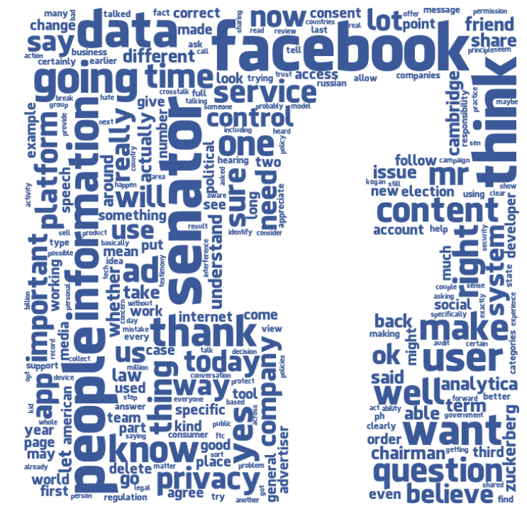

```python
#word cloud from all Raw text
show_words_cloud(testimonyDF.Text.str.cat(sep=' '), None, 250, None)
```

#### Data pre-processing:

1. Use stop words from nltk and add custom words
2. Replace common misspellings
3. clean up punctuation, new line, white space, html and unicode characters
4. tokenize using nltk library
5. Use count vectorizer almost identical to basicCV but with cleaned tokens from corpus and using stop words

```python
import html
# replace contractions
# code borrowed from http://stackoverflow.com/questions/27845796/replacing-words-matching-regular-expressions-in-python
import re

replacement_patterns = [
(r'won\'t', 'will not'),
(r'can\'t', 'cannot'),
(r'can\'t', 'cannot'),
(r'u\.s', 'united states'),
(r'ain\'t', 'is not'),
(r'(\w+)\'ll', '\g<1> will'),
(r'(\w+)n\'t', '\g<1> not'),
(r'(\w+)\'ve', '\g<1> have'),
(r'(\w+)\'s', '\g<1> is'),
(r'(\w+)\'re', '\g<1> are'),
(r'(\w+)\'d', '\g<1> would'),
(r'(\r|\n)', ' '),
('([.,!?()])', ''),
('\s{2,}', ' ')
]

zuck_dict = {'united states':'u.s', 'years':'year', 'states':'state', '--':',', 'senator yes':'yes senator',
            'think senator' : 'senator think', 'believe senator' : 'senator believe', 'senator thank': 'thank senator',
            'yeah' :'yes', 'hate-speech':'hate speech'}

class RegexpReplacer(object):
    def __init__(self, patterns=replacement_patterns):
        self.patterns = [(re.compile(regex), repl) for (regex, repl) in patterns]
    def replace(self, text):
        s = text
        for (pattern, repl) in self.patterns:
            (s, count) = re.subn(pattern, repl, s)
        return s

# using dictionaries
def multiple_replace(text):
    text = str(text).lower()
    # Create a regular expression  from the dictionary keys
    regex = re.compile("(%s)" % "|".join(map(re.escape, dict.keys())))
    # For each match, look-up corresponding value in dictionary
    return regex.sub(lambda mo: zuck_dict[mo.string[mo.start():mo.end()]], text)

replacer = RegexpReplacer()
def cleanText(text):
    try:
        if hasattr(text, '__iter__'):
            text = html.unescape(text)
            text = text.encode('utf-8').decode('ascii')
        text = replacer.replace(text)
        text = multiple_replace(text)
    except UnicodeDecodeError:
        text = ''
    except Exception:
        pass
    #print(text)
    return text
```

```python
#create an object storing the default nltk stopwords
from nltk.corpus import stopwords

nltk_stopwords = stopwords.words("english")
stopwords = nltk_stopwords + ["mr", "thanks","ph", "yeah", "ok","let", "ms", "go", 'going', "would", "well", "data", "facebook", "senator",
                             "zuckerberg", "i'm", "chairman", "know", "think", "want", "get",
                             "could", "make", "making", "might", "also", "one", "lot", "today",
                             "thing", "things", "made", "put", "information", "said", "third", "got",
                             "way", "taken", "whether", "say", "something", "people", "user", "users",
                             "company", "two", "thank", "service", "content","system","platform", "see", "look"]
```

```python
# NLTK also has tokenizers
from nltk import word_tokenize

def tokenize(row, stop_words):
    text = cleanText(row.lower())
    wordList = str(text.lower()).split() #splits the text apart before stemming
    token2Text = ''
    tokenText = [word_tokenize(word) for word in wordList] #tells it which stemmer to apply and how
    token2Text = ' '
    for token in tokenText:
        token = (' '.join(map(str, token)))
        #print(token, " is in", token not in stopwords )
        if token not in stop_words:
            #print(' '.join(map(str, token)))
            token2Text = token2Text + " " + token + " " #puts everything back together again
    return token2Text

testimonyDF['tokenText'] = testimonyDF["Text"].apply(lambda x: tokenize(x, stopwords))
```

```python
processedCV = CountVectorizer(stop_words= stopwords, ngram_range=(1,4), min_df=2, max_df=1.0, binary = False)
afterText = featureCounts(processedCV, testimonyDF['tokenText'])
```

```
Feature space: tokenText (858, 2456)
```

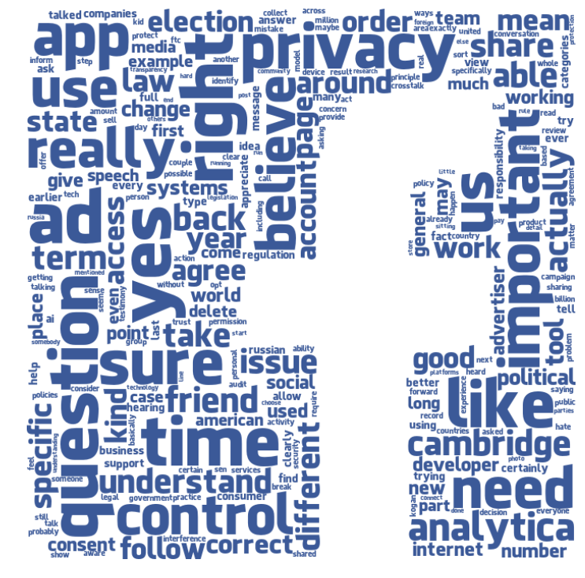

```python
show_words_cloud(testimonyDF.tokenText.str.cat(sep=' '), stopwords, 250, None)
```

## Sentiment dictionaries

Sentiment Engine is built with the combination of Afinn and GI dictionaries:

GI dictionary groups words in to categories. Some example categories used in this exercise: affect, feelings, political, legal. Words in each of these categories signify sentiments like positive, negative, strong, weak and neutral.

```python
#some dictionaries assign a value
afinn = {}
for line in open("AFINN-111.txt"):
    tt = line.split('\t')
    afinn.update({tt[0]:int(tt[1])})
```

```python
#new GI dictionary
import re
GI_frame = pd.read_csv('inquirerbasic.csv',
                       usecols=[0,1,2,3,6,7,8,10,15,16,18,19,20,21,22,29,32,64,65,66,68,70,112,113,114,177,178,184,185],
                      na_values = [" "])


GI_frame.fillna('', inplace=True)
# get rid of multiple counts
GI_frame['NewEntry'] = GI_frame['Entry'].str.extract('([A-Z]\w{0,})', expand = False)
```

### Use the dictionaries to construct a measure or build our Sentiment Engine

```python
#let's create lists: pos, neg, strong, weak
GIlist = GI_frame['NewEntry'].tolist()
GIlist = list(map(lambda x: str(x).lower(), GIlist))
GIset = set(GIlist)

#positive sentiment
GIpos = GI_frame['NewEntry'][GI_frame['Positiv'].str.contains('Positiv')].tolist()
GIyes = GI_frame['NewEntry'][GI_frame['Yes'].str.contains('Yes')].tolist()
GIposAff = GI_frame['NewEntry'][GI_frame['PosAff'].str.contains('PosAff')].tolist()
GIfeel = GI_frame['NewEntry'][GI_frame['Feel'].str.contains('Feel')].tolist()
GIemot = GI_frame['NewEntry'][GI_frame['EMOT'].str.contains('EMOT')].tolist()

#negative sentiment
GIneg = GI_frame['NewEntry'][GI_frame['Negativ'].str.contains('Negativ')].tolist()
GIno = GI_frame['NewEntry'][GI_frame['No'].str.contains('No')].tolist()
GInegAff = GI_frame['NewEntry'][GI_frame['NegAff'].str.contains('NegAff')].tolist()
GIpain = GI_frame['NewEntry'][GI_frame['Pain'].str.contains('Pain')].tolist()
GIfail = GI_frame['NewEntry'][GI_frame['Fail'].str.contains('Fail')].tolist()
GIhostile = GI_frame['NewEntry'][GI_frame['Hostile'].str.contains('Hostile')].tolist()
#negate
GInegate = GI_frame['NewEntry'][GI_frame['Negate'].str.contains('Negate')].tolist()

#strong sentiment
GIstrong = GI_frame['NewEntry'][GI_frame['Strong'].str.contains('Strong')].tolist()
GIvirtue = GI_frame['NewEntry'][GI_frame['Virtue'].str.contains('Virtue')].tolist()
GIpersist = GI_frame['NewEntry'][GI_frame['Persist'].str.contains('Persist')].tolist()

#weak sentiment
GIweak = GI_frame['NewEntry'][GI_frame['Weak'].str.contains('Weak')].tolist()
GIvice = GI_frame['NewEntry'][GI_frame['Vice'].str.contains('Vice')].tolist()

#neutral sentiment
GIovrst = GI_frame['NewEntry'][GI_frame['Ovrst'].str.contains('Ovrst')].tolist()
GIundrst = GI_frame['NewEntry'][GI_frame['Undrst'].str.contains('Undrst')].tolist()
GIpolit = GI_frame['NewEntry'][GI_frame['POLIT'].str.contains('POLIT')].tolist()
GIlegal = GI_frame['NewEntry'][GI_frame['Legal'].str.contains('Legal')].tolist()
GIneed = GI_frame['NewEntry'][GI_frame['Need'].str.contains('Need')].tolist()
GIgoal = GI_frame['NewEntry'][GI_frame['Goal'].str.contains('Goal')].tolist()
GItry = GI_frame['NewEntry'][GI_frame['Try'].str.contains('Try')].tolist()

GIpos = list(map(lambda x: str(x).lower(), GIpos))
GIpos.extend(list(map(lambda x: str(x).lower(), GIyes)))
GIpos.extend(list(map(lambda x: str(x).lower(), GIposAff)))
#GIpos.extend(list(map(lambda x: str(x).lower(), GIfeel)))
#GIpos.extend(list(map(lambda x: str(x).lower(), GIemot)))

GIneg = list(map(lambda x: str(x).lower(), GIneg))
GIneg.extend(list(map(lambda x: str(x).lower(), GIno)))
GIneg.extend(list(map(lambda x: str(x).lower(), GInegAff)))
GIneg.extend(list(map(lambda x: str(x).lower(), GIpain)))
GIneg.extend(list(map(lambda x: str(x).lower(), GIfail)))

GIstatement = list(map(lambda x: str(x).lower(), GIovrst))
GIstatement.extend(list(map(lambda x: str(x).lower(), GIundrst)))
GIstatement.extend(list(map(lambda x: str(x).lower(), GIpolit)))
GIstatement.extend(list(map(lambda x: str(x).lower(), GIlegal)))
GIstatement.extend(list(map(lambda x: str(x).lower(), GIneed)))
GIstatement.extend(list(map(lambda x: str(x).lower(), GIgoal)))
GIstatement.extend(list(map(lambda x: str(x).lower(), GItry)))

GIstrong = list(map(lambda x: str(x).lower(), GIstrong))
GIstrong.extend(list(map(lambda x: str(x).lower(), GIvirtue)))
GIstrong.extend(list(map(lambda x: str(x).lower(), GIpersist)))

GIweak = list(map(lambda x: str(x).lower(), GIweak))
GIweak.extend(list(map(lambda x: str(x).lower(), GIvice)))
```

```python
#more complicated sentiment calculations
#amplification and negation words from qdap
penalty=["hate", "hate-speech", "interrupt", "interrupting", "refuse", "terror",
         "incite genocide", "genocide", "death", "russia", "breached","self-harm",
         "interference", "interfering","bias", "addiction"]

GIneg.extend(["aint", "scandal","lax", "frustrate","apologize", "sorry","arent","cant",
              "couldnt","obligation", "but", "did not", "didnt" , "doesnt" ,"dont" ,"hasnt",
              "isnt" ,"mightnt" , "mustnt" ,"neither" ,"never", "no" ,"nobody" , "nor",
              "not" , "shant", "shouldnt", "wasnt" , "werent" ,"wont", "wouldnt"])

GIstrong.extend(["acute","acutely",'absolutely', "certain", "certainly", "clear" ,
                 "colossal", "colossally","deep" , "deeply" , "definite","definitely",
                 "enormous","enormously" , "extreme", "extremely" ,"great","greatly",
                 "heavily", "heavy", "high","highly" ,"huge","hugely" , "immense",
                 "immensely" ,"incalculable" ,"incalculably","massive", "massively",
                 "more","particular","particularly","purpose", "purposely", "quite"
                 ,"real" ,"really","serious", "seriously", "severe","severely" ,"significant"
                 ,"significantly","sure","surely","thank", "true", "truly", "vast",
                 "vastly" , "very"])
```

Negative words are multiplied by negative scale and reduce the overall value of sentiment Positive words are multiplied by positive scale and increase the overall value of sentiment Strong words amplify the sentiment and Weak words dilute the sentiment significantly Neutral words use the value speicifed in Afinn with no scale

In the end, if the total sentiment is a positive integer sentiment of the text is positive and vice versa. If sentiment is 0, it is marked as neutral.

If penalty is chosen, any text that contains one or more penalty words will be labeled Negative sentiment.

```python
#If key error or other exception, uses 1 as neutral value
def getAfinnVal(word, scale):
    try:
        return scale*afinn[word]
    except:
        return scale

def sentiment(inputstring, penalize=False):

    sentcount=0
    i=0
    negativeCtx=0
    #default scale values if word not found in Afinn
    weakScale=0.5
    posScale=2
    negScale=-2
    strongScale=4
    neutralScale=1

    for word in inputstring.split():
        prev = inputstring.split().pop(i-1)
        if word in penalty:
            negativeCtx+=1
            sentcount = sentcount-10000
        elif (prev in GIneg or word in GIneg):
            sentcount = sentcount + getAfinnVal(word, negScale) + getAfinnVal(prev, negScale)
        elif (prev in GIstrong or word in GIstrong):
            sentcount = getAfinnVal(prev, strongScale)*(sentcount + getAfinnVal(word, strongScale))
        elif (prev in GIweak) and getAfinnVal(prev,neutralScale) > 0:
            sentcount = (sentcount + getAfinnVal(word, weakScale))/getAfinnVal(prev,neutralScale)
        elif (prev in GIstatement):
            sentcount = (sentcount + getAfinnVal(word,neutralScale) * weakScale)
        else:
            sentcount = sentcount + getAfinnVal(word,neutralScale)
            i+=1

    #If the sentence has any penalty words, return Negative
    if (sentcount < 0 or (penalize and negativeCtx > 0)):
        sentiment = 'Negative'
    elif (sentcount >0):
        sentiment = 'Positive'
    else:
        sentiment = 'Neutral'
    #print(sentiment,"\n****************\n")
    return sentiment
```

### How did processing data change the sentiment labels?

```python
testimonyDF['RawSentiment'] = testimonyDF['Text'].apply(lambda x: sentiment(x))
```

```python
testimonyDF['TokenSentiment'] = testimonyDF['tokenText'].apply(lambda x: sentiment(x))
```

```python
#Count no. of matching vs different labels
matchingSentiment = testimonyDF[(testimonyDF['RawSentiment'] == testimonyDF['TokenSentiment'])]
nonMatchingSentiment = testimonyDF[(testimonyDF['RawSentiment'] != testimonyDF['TokenSentiment'])]

print(len(matchingSentiment))
print(len(nonMatchingSentiment))
```

```
601
257
```

```python
#a few specific examples with surprising labels
nonMatchingSentiment.iloc[[1,2,4,8,15,255]]
```

|  | Person | Text | tokenText | RawSentiment | TokenSentiment |
| --- | --- | --- | --- | --- | --- |
| 13 | NELSON: | ok.\r\n\r\n |  | Positive | Neutral |
| 15 | NELSON: | but -- so, therefore, you consider my personally identifiable data the company's data, not my data. is that it?\r\n\r\n | -- therefore consider personally identifiable | Negative | Positive |
| 21 | NELSON: | yes, you did that, and you apologized for it. but you didn't notify them. and do you think that you have an ethical obligation to notify 87 million facebook users?\r\n\r\n | yes apologized notify ethical obligation notify 87 million | Negative | Positive |
| 31 | THUNE: | well -- and i'm glad that you all have gotten that message.\r\n\r\nas we discussed in my office yesterday, the line between legitimate political discourse and hate speech can sometimes be hard to iden… | -- i 'm glad gotten message discussed office yesterday line legitimate political discourse hate speech sometimes hard identify especially relying artificial intelligence technologies initial discovery… | Positive | Negative |
| 57 | ZUCKERBERG: | senator, i have not heard that.\r\n\r\n | heard | Neutral | Positive |
| 855 | GRASSLEY: | \r\n\r\nwithout objection, so ordered.\r\n | without objection ordered | Positive | Negative |

```python
#crosstab the difference
import pandas as pd
import matplotlib.pyplot as plt
import numpy as np
import seaborn as sns

print("Sentiment Raw vs Tokenized text\n")
FeelingRaw = testimonyDF.RawSentiment
FeelingToken = testimonyDF.TokenSentiment
print(pd.crosstab(FeelingRaw, FeelingToken, margins=True))
```

```
Sentiment Raw vs Tokenized text

TokenSentiment  Negative  Neutral  Positive  All
RawSentiment
Negative              48        2        94  144
Neutral               11        1        35   47
Positive              52       63       552  667
All                  111       66       681  858
```

#### Update processed text based on the observations from the analysis so far. Do not eliminate 'not' from stop words, use penalty with sentiment engine

```python
stopwords2 = stopwords
stopwords2.remove('not')
tokenPenaltyText = testimonyDF["Text"].apply(lambda x: tokenize(x, stopwords2))
testimonyDF['TokenSentimentPenalty'] = tokenPenaltyText.apply(lambda x: sentiment(x, True))
testimonyDF['TokenText2'] = tokenPenaltyText
```

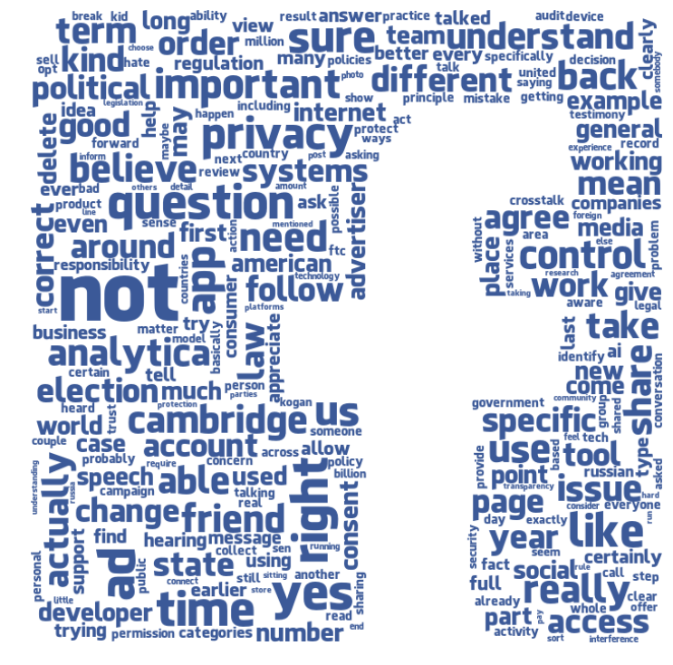

```python
show_words_cloud(testimonyDF.TokenText2.str.cat(sep=' '), stopwords, 250, None)
```

```python
#show the difference in sentiments of raw, processed, processed improv text
matchingSent = testimonyDF[(testimonyDF['TokenSentiment'] == testimonyDF['TokenSentimentPenalty'])]
nonMatchingSent = testimonyDF[(testimonyDF['RawSentiment'] != testimonyDF['TokenSentiment'])]
nonMatchingSent2 = testimonyDF[(testimonyDF['TokenSentiment'] != testimonyDF['TokenSentimentPenalty'])]
nonMatchingSent3 = testimonyDF[(testimonyDF['RawSentiment'] != testimonyDF['TokenSentimentPenalty'])]

print("matching raw vs processed=", len(matchingSent))
print("non-matching raw vs processed=", len(nonMatchingSent))
print("non-matching processed vs processed+improv=", len(nonMatchingSent2))
print("non-matching raw vs processed+improv=", len(nonMatchingSent3))
```

```
matching raw vs processed= 768
non-matching raw vs processed= 257
non-matching processed vs processed+improv= 90
non-matching raw vs processed+improv= 275
```

#### A few specific examples how the improved processing changes the sentiment of text

```python
nonMatchingSent.iloc[[1,3,6,15]]
```

|  | Person | Text | tokenText | RawSentiment | TokenSentiment | TokenSentimentPenalty | TokenText2 |
| --- | --- | --- | --- | --- | --- | --- | --- |
| 13 | NELSON: | ok.\r\n\r\n |  | Positive | Neutral | Neutral |  |
| 16 | ZUCKERBERG: | no, senator. actually, at -- the first line of our terms of service say that you control and own the information and content that you put on facebook.\r\n\r\n | actually -- first line terms control | Negative | Positive | Positive | actually -- first line terms control |
| 26 | THUNE: | and -- and, mr. zuckerberg, would you that -- do that differently today, presumably? that -- in response to senator nelson's question...\r\n\r\n | -- -- differently presumably -- response nelson question | Neutral | Positive | Positive | -- -- differently presumably -- response nelson question |
| 57 | ZUCKERBERG: | senator, i have not heard that.\r\n\r\n | heard | Neutral | Positive | Negative | not heard |

```python
#cross tab
print("Sentiments Raw vs Tokenized text with Penalty for too many negative words\n")
FeelingRaw = testimonyDF.RawSentiment
FeelingToken = testimonyDF.TokenSentimentPenalty
print(pd.crosstab(FeelingRaw, FeelingToken, margins=True))
```

```
Sentiments Raw vs Tokenized text with Penalty for too many negative words

TokenSentimentPenalty  Negative  Neutral  Positive  All
RawSentiment
Negative                     74        2        68  144
Neutral                      23        0        24   47
Positive                    100       58       509  667
All                         197       60       601  858
```

```python
#Save
testimonyDF.to_csv('ZuckTestimonySentiment.csv', encoding='utf-8')
```

POS tagging

```python
import nltk

def pos_tag(row):
    tokenText = word_tokenize(cleanText(row))
    #print(tokenText)
    token2Text = nltk.pos_tag(tokenText)
    #print(token2Text)
    return token2Text

testimonyDF['pos'] = testimonyDF["Text"].apply(lambda x: pos_tag(x))
```

```python
#Simple sentiment engine with PoS tagging
def sentiment2(inputstring, penalize=False):

    sentcount=0
    i=0
    #default scale values if word not found in Afinn
    weakScale=0.5
    posScale=2
    negScale=-2
    strongScale=4
    neutralScale=1
    scale = 0
    for word in inputstring:
        prev = inputstring[i-1]
        #ignore pronouns, conjunctions, nouns as neutral/non-important words
        if word[1] in ['CC', 'PRP', 'PRP$', 'NN', 'NNS', 'NNP', 'NNPS', 'WP', 'WP$']:
            scale = neutralScale
        elif word[0] in GIneg or prev in GIneg:
            scale = negScale
        elif word[0] in GIpos:
            scale = posScale
        elif word[0] in GIstrong:
            scale = strongScale
        elif word[0] in GIweak:
            scale = weakScale
        sentcount += getAfinnVal(word[0], scale)

    #If the sentence has any penalty words, return Negative
    if (sentcount < 0):
        sentiment = 'Negative'
    elif (sentcount >0):
        sentiment = 'Positive'
    else:
        sentiment = 'Neutral'
    #print(sentiment,"\n****************\n")
    return sentiment
```

```python
testimonyDF['posSent'] = testimonyDF['pos'].apply(lambda x: sentiment2(x))
```

```python
#show the difference in sentiments of processed vs processed+PoS text
matchingSentPos = testimonyDF[(testimonyDF['TokenSentiment'] == testimonyDF['posSent'])]
nonMatchingSentPos = testimonyDF[(testimonyDF['TokenSentiment'] != testimonyDF['posSent'])]

print("matching before vs after PoS=", len(matchingSentPos))
print("non-matching before vs after PoS=", len(nonMatchingSentPos))
```

```
matching before vs after PoS= 672
non-matching before vs after PoS= 186
```

```python
#cross tab
print("Sentiments before vs after PoS\n")
FeelingProc = testimonyDF.TokenSentiment
FeelingPos = testimonyDF.posSent
print(pd.crosstab(FeelingProc, FeelingPos, margins=True))
```

```
Sentiments before vs after PoS

posSent         Negative  Neutral  Positive  All
TokenSentiment
Negative               4        0       107  111
Neutral                3        3        60   66
Positive              12        4       665  681
All                   19        7       832  858
```

Many of the neutral and negative comments are now marked Positive, as we also updated the Sentiment engine to be simpler than before

```python
testimonyDF.to_csv('ZuckTestimonyPOS.csv', encoding='utf-8')
```